# Math 534 Assignment 3

Jose Luis Gonzalez

2/13/2018

## Problem 1

### 1.1 Secant Method Function

```r
# Secant Method
# Gradient
grad <- function(x,t){
  # x = c(x1, x2, x3, x4)
dl = x[1]/(2+t) - (x[2] + x[3])/(1 - t) + x[4]/t
}

# Secant Method
maxit <- 20 # Max number of iterations
x = c(1997, 907, 904, 32)
# t0 = t^(n-1) t1 =t^(n)

sec <- function(maxit, x, t0, t1, tolgrad, tollerr){
  # Creates empty matrix to input iteration values
  values <- matrix(NA, nrow  = maxit, ncol = 4,
                   dimnames = list(rep("",maxit),c("IT","T(n)","MRE", "dl(T(n))")))
  count <- 0
  tol <- TRUE
  while(maxit > 0 && tol == TRUE) {
  count <- count + 1 # counts the number of iterations
  dl_0 <- grad(x,t0)
  dl_1 <- grad(x,t1)
  t_new <-  t1 - dl_1*(t1-t0)/(dl_1-dl_0)
  mre <- abs(t1-t0)/max(1,abs(t1)) # Modified Relative Error

  values[count,] <- c(format(count, digits = 0), formatC(t1,digits = 12, format = "f"),
                      format(x = mre,scientific = TRUE, digits = 2),
                      format(x = dl_1, scientific = TRUE, digits = 2))

  # reassign t0, t1
  t0 = t1
  t1 = t_new
  maxit <- maxit - 1 # updates the number of iterations left to perform

  # Check if tolgrad and tollerr conditions were met
  if(dl_1 < tolgrad && mre < tollerr){
    tol <- FALSE # If both conditions are met, tol <- FALSE breaks the while loop
  }else{}
  }
print(values[1:count,], quote = FALSE) # Prints Matrix of Iteration Outputs
}
```

### 1.2 Apply Secent Method

```r
# Running sec with t0 =.02, t1=.01, tolerr = 1e-6, and tolgrad = 1e-9
sec(maxit = maxit,x = x,t0 = .02,t1 = .01,tolgrad = 1e-9, tollerr = 1e-6)
```

```
##  IT T(n)           MRE     dl(T(n))
##  1  0.010000000000 1e-02   2.4e+03
##  2  0.024561848011 1.5e-02 4.3e+02
##  3  0.027823212918 3.3e-03 2.7e+02
##  4  0.033351047002 5.5e-03 6.8e+01
##  5  0.035197558267 1.8e-03 1.3e+01
##  6  0.035646185180 4.5e-04 7.9e-01
##  7  0.035674309037 2.8e-05 9.6e-03
##  8  0.035674655571 3.5e-07 6.9e-06
##  9  0.035674655823 2.5e-10 6.1e-11
```

### 1.3

```r
sec_c <- function(maxit, x, t0, t1, tolgrad, tollerr){
  # Creates empty matrix to input iteration values
  values <- matrix(NA, nrow  = maxit, ncol = 4,
                   dimnames = list(rep("",maxit),c("IT","T(n)", "Const. Conv.", "Sig.Digits")))
  count <- 0
  tol <- TRUE
  tstar <- (-1657 + sqrt(3728689))/7680
  while(maxit > 0 && tol == TRUE) {
    count <- count + 1 # counts the number of iterations
    dl_0 <- grad(x,t0)
    dl_1 <- grad(x,t1)
    t_new <-  t1 - dl_1*(t1-t0)/(dl_1-dl_0)
    mre <- abs(t1-t0)/max(1,abs(t1))
    con_cov <- abs(t1 - tstar)/abs(t0 - tstar)
    sigdig <- -log10(abs(t1 - tstar)/abs(tstar))
    # replace values in matrix

    values[count,] <- c(format(count, digits = 0), formatC(t1,digits = 12, format = "f"),
                        format(x = con_cov,scientific = TRUE, digits = 2),
                        format(x = sigdig, digits = 2))

    # reassign t0, t1
    t0 = t1
    t1 = t_new
    maxit <- maxit - 1 # updates the number of iterations left to perform

    # Check if tolgrad and tollerr conditions were met
    if(dl_1 < tolgrad && mre < tollerr){
      tol <- FALSE # If both conditions are met, tol <- FALSE  breaks the while loop
    }else{}
  }
  print(values[1:count,], quote = FALSE) # Prints Matrix of Iteration Outputs
}


sec_c(maxit = maxit,x = x,t0 = .02,t1 = .01,tolgrad = 1e-9, tollerr = 1e-6)
```

```
##  IT T(n)           Const. Conv. Sig.Digits
##  1  0.010000000000 1.6e+00      0.14
##  2  0.024561848011 4.3e-01      0.51
##  3  0.027823212918 7.1e-01      0.66
##  4  0.033351047002 3e-01        1.2
##  5  0.035197558267 2.1e-01      1.9
##  6  0.035646185180 6e-02        3.1
##  7  0.035674309037 1.2e-02      5
##  8  0.035674655571 7.3e-04      8.2
##  9  0.035674655823 8.8e-06      13
```

Based on the constant of convergance from part c) it appears that the secant method is super linearly convergant as the constant of convergance, abs(t1 - tstar)/abs(t0 - tstar), converges to 0. At the 9th iteration, the constant of convergence is 8.8e-06, which is approximately 0.

### 1.4

```r
sec_c(maxit = maxit,x = x,t0 = .5,t1 = .01,tolgrad = 1e-9, tollerr = 1e-6)
```

```
##  IT T(n)                Const. Conv. Sig.Digits
##  1  0.010000000000      5.5e-02      0.14
##  2  0.236113205980      7.8e+00      -0.75
##  3  0.154232612419      5.9e-01      -0.52
##  4  -0.091534935810     1.1e+00      -0.55
##  5  -5.415293039221     4.3e+01      -2.2
##  6  -57.393356615762    1.1e+01      -3.2
##  7  -61.758036194809    1.1e+00      -3.2
##  8  -118.507564138350   1.9e+00      -3.5
##  9  -179.641949878101   1.5e+00      -3.7
##  10 -297.549730154520   1.7e+00      -3.9
##  11 -476.603259666372   1.6e+00      -4.1
##  12 -773.572321173815   1.6e+00      -4.3
##  13 -1249.599529131543  1.6e+00      -4.5
##  14 -2022.598694332578  1.6e+00      -4.8
##  15 -3271.626847784568  1.6e+00      -5
##  16 -5293.655269176950  1.6e+00      -5.2
##  17 -8564.712525064278  1.6e+00      -5.4
##  18 -13857.798623401799 1.6e+00      -5.6
##  19 -22421.942237832507 1.6e+00      -5.8
##  20 -36279.172111427077 1.6e+00      -6
```

The secant method does not converge given t0 = .5, t1 = .01. This is because the secant line of the inital points lead to a new t1 and t0 set of points with a flat secant line that produces a negative values as its solution. As the iterations continue, the solutions become more negative as they are following the asymptote on the negative side.

## Problem 2

Consider the density $f(x) = [1 - cos(x-\theta)]/2\pi$ on $0 \leq x \leq 2\pi$, where is parameter between $-\pi$ and $\pi$. The follwing i.i.d. data arise from thise density: 3.91, 4.85, 2.28, 4.06, 3.70, 4.04, 5.46, 3.53, 2.28, 1.96, 2.53, 3.88, 2.22, 3.47, 4.82, 2.46, 2.99, 2.54, 0.52, 2.50. We wish to estimate $\theta$.

### 2.1 Graph the log likelihood function between $-\pi$ and $\pi$.

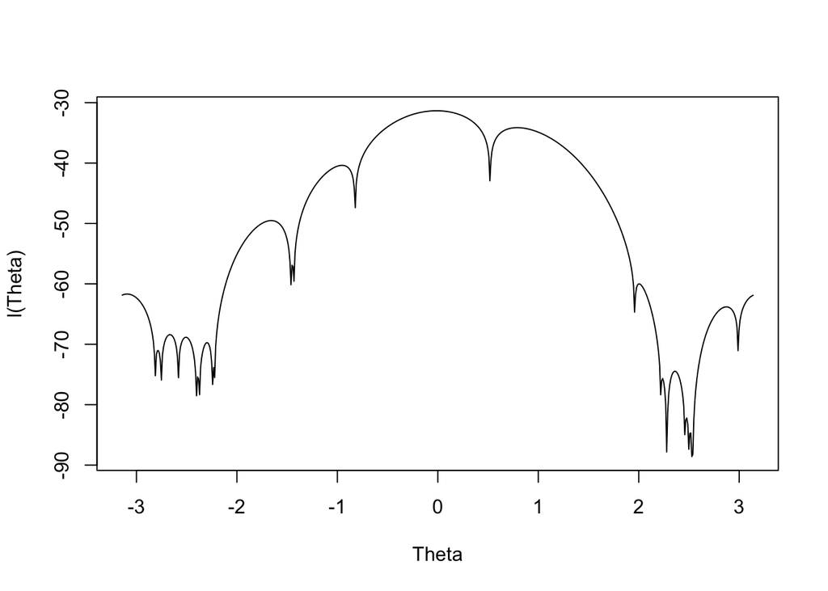

```r
x <- c(3.91, 4.85, 2.28, 4.06, 3.70, 4.04, 5.46, 3.53, 2.28, 1.96, 2.53, 3.88,
       2.22, 3.47, 4.82, 2.46, 2.99, 2.54, 0.52, 2.50)
theta <- seq(-pi, pi, by =.01)
like <- function (x, theta) {
  log_plot <- rep(0,length(theta))
  sum_log <- rep(0, length(x))
  for(i in 1:length(theta)){
    for(j in 1:length(x)){
   sum_log[j] <- log(1-cos(x[j]-theta[i])) -log(2*pi)
    }
    log_plot[i] <- sum(sum_log)
  }
  plot(x = theta, y = log_plot, type = 'l', xlab = "Theta", ylab = "l(Theta)")
}

like(x = x, theta = theta)
```

### 2.2 Find the Method of Moments Estimator

```r
# Method of Moments Estimator
x <- c(3.91, 4.85, 2.28, 4.06, 3.70, 4.04, 5.46, 3.53, 2.28, 1.96, 2.53, 3.88,
       2.22, 3.47, 4.82, 2.46, 2.99, 2.54, 0.52, 2.50)
x_bar <- mean(x)
theta0 <- asin(x_bar - pi)

print(paste("The method of moments estimator is", theta0))
```

```
## [1] "The method of moments estimator is 0.0584406061404241"
```

### 2.3 Find the MLE of $\theta$ using the Newton-Ralphson method, using the result from 2.2 as the starting value. What solutions do you find when you start at -2.7 and 2.7?

```r
# (c) Find the MLE using Newtons Method and theta0 as starting point

# Gradient
grad <- function(x,t){
  grad_val <- rep(0,length(t))
  sum_grad <- rep(0,length(x))
  for(i in 1:length(t)){
    for(j in 1:length(x)){
      sum_grad[j] <- -sin(x[j] - t[i])/(1-cos(x[j] - t[i]))
    }
    grad_val[i] <- sum(sum_grad)
  }
  return(grad_val)
}


# Hessian

hess <- function(x,t){
  hess_val <- rep(0, length(t))
  sum_hess <- rep(0, length(x))
  for(i in 1:length(t)){
    for(j in 1:length(x)){
      sum_hess[j] <- (cos(x[j] - t[i])*(1-cos(x[j] - t[i])) -
                        (sin(x[j] - t[i]))^2)/(1 - cos(x[j] - t[i]))^2
    }
    hess_val[i] <- sum(sum_hess)
  }
  return(hess_val)
}

# Newton's Method
newt <- function(maxit, x, t, tolgrad, tollerr){
  values <- matrix(0, ncol = 4, nrow = maxit,
                   dimnames = list(rep("", maxit), c("IT", "T(n)", "MRE", "dl(T(n))")))
  count <- 0
  tol <- TRUE
  while(maxit > 0 && tol == TRUE) {
  count <- count + 1
  grad_val <- grad(x,t)
  hess_val <- hess(x,t)
  t_new <- t - grad_val/hess_val
  mre <- abs(t_new - t)/max(1,abs(t_new))
  # Matrix
  values[count,] <- c(format(count, digits = 0), formatC(t,digits = 12,format = "f"),
                      format(x = mre, scientific = TRUE, digits = 2),
                      format(x = grad_val, scientific = TRUE, digits = 2))

  # Reassign
  t <- t_new
  maxit <- maxit - 1
  # Check if tolgrad and tollerr conditions were met
  if(grad_val < tolgrad && mre < tollerr){
    tol <- FALSE # If both conditions are met, tol <- FALSE breaks the while loop
  }else{}
  }
  print(values[1:count,], quote = FALSE) # Prints Matrix of Iteration Outputs
}

# MME = theta0
newt(maxit = 20, x = x, t = theta0 , tolgrad = 10^(-9), tollerr = 10^(-6))
```

```
##  IT T(n)            MRE     dl(T(n))
##  1  0.058440606140  6.8e-02 -1.6e+00
##  2  -0.009098573745 2.9e-03 -6.3e-02
##  3  -0.011968737913 3.3e-06 -7.2e-05
##  4  -0.011972002283 4.1e-12 -9.1e-11
```

```r
# Solutions given t0 = -2.7, t0 = 2.7, respectively
newt(maxit = 20, x = x, t = -2.7 , tolgrad = 10^(-9), tollerr = 10^(-6))
```

```
##  IT T(n)            MRE     dl(T(n))
##  1  -2.700000000000 9.7e-03 2.8e+01
##  2  -2.674113655831 2.7e-03 5.5e+00
##  3  -2.666793927068 3.5e-05 7e-02
##  4  -2.666699927130 3.9e-10 7.6e-07
##  5  -2.666699926101 1.7e-16 4.5e-13
```

```r
newt(maxit = 20, x = x, t = 2.7 , tolgrad = 10^(-9), tollerr = 10^(-6))
```

```
##  IT T(n)           MRE     dl(T(n))
##  1  2.700000000000 4.4e-02 3.9e+01
##  2  2.825724484570 1.8e-02 1e+01
##  3  2.877549108301 1.5e-03 -1.1e+00
##  4  2.873184456115 3.1e-05 -2.3e-02
##  5  2.873094549040 1.2e-08 -8.7e-06
```

### 2.4 Repeat 2.3using 200 equally spaced starting values between $-\pi$ and $\pi$.

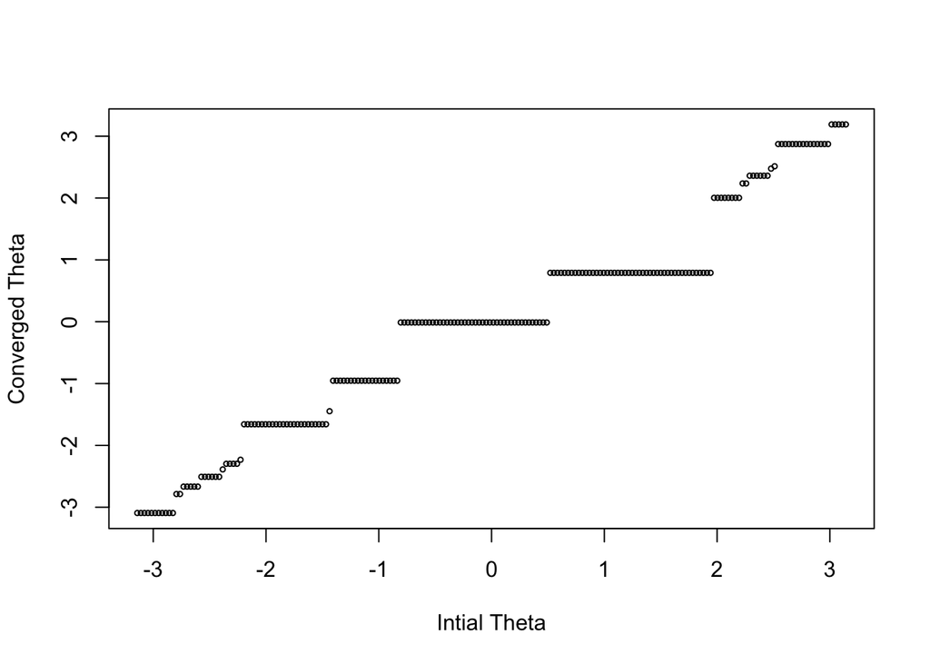

```r
# d)
# Newton's Method 200 graphically
newt_graph <- function(maxit, x, t, tolgrad, tollerr){
  value_graph <- matrix(0, nrow = length(t), ncol = 2)
  for ( i in 1:length(t)){
  values <- matrix(0, ncol = 4, nrow = maxit,
                   dimnames = list(rep("", maxit), c("IT", "T(n)", "MRE", "dl(T(n))")))
  count <- 0
  tol <- TRUE
  t0 <- t[i]
  max <- maxit
  while(max > 0 && tol == TRUE) {
    count <- count + 1
    grad_val <- grad(x,t0)
    hess_val <- hess(x,t0)
    t_new <- t0 - grad_val/hess_val
    mre <- abs(t_new - t0)/max(1,abs(t_new))
    # Matrix
    values[count,] <- c(format(count, digits = 0), formatC(t0,digits = 12, format = "f"),
                        format(x = mre, scientific = TRUE, digits = 2),
                        format(x = grad_val, scientific = TRUE, digits = 2))

    # Reassign
    t0 <- t_new
    max <- max - 1
    # Check if tolgrad and tollerr conditions were met
    if(grad_val < tolgrad && mre < tollerr){
      tol <- FALSE # If both conditions are met, tol <- FALSE breaks while loop
      }else{}
  }
  value_graph[i,] <- c(t[i], values[count,2])
  }
  plot(x = value_graph[,1], y = value_graph[,2], cex = .5, xlab = "Intial Theta", ylab = "Converged Theta")
}



newt_graph(maxit = 20,x = x, t = seq(-pi,pi, length.out = 200), tolgrad = 10^(-9), tollerr = 10^(-6))
```

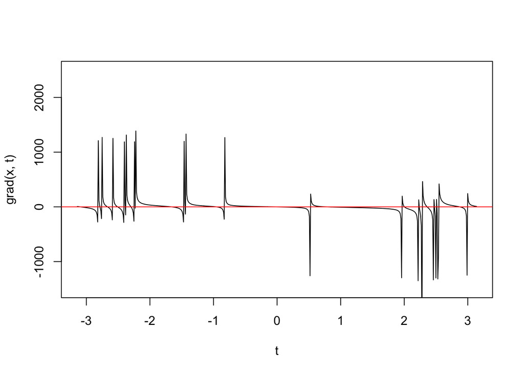

```r
# Plot Gradient
t <- seq(-pi, pi, by = .01)
plot(x = t, y = grad(x, t), type = "l", ylim = c(-1500, 2500))
abline(h=0, col = "red")
```

### 2.5 Find two starting values, as nearly equal as you can, for which the Newton-Rapshon method converges to two different solutions.

```r
# e) The two numbers chosen are -0.836705581106829 and -0.805131785593364
newt(maxit = 20, x = x, t = -0.836705581106829, tolgrad = 10^(-9),tollerr = 10^(-6))
```

```
##  IT T(n)            MRE     dl(T(n))
##  1  -0.836705581107 1.2e-02 -1.4e+02
##  2  -0.849079620001 2.2e-02 -6.5e+01
##  3  -0.870592525653 3.2e-02 -2.9e+01
##  4  -0.902396194404 3.3e-02 -1.1e+01
##  5  -0.935187279786 1.6e-02 -3e+00
##  6  -0.951255830566 2.1e-03 -3.1e-01
##  7  -0.953310711214 2.6e-05 -3.8e-03
##  8  -0.953336323884 3.8e-09 -5.7e-07
```

```r
newt(maxit = 20, x = x, t = -0.805131785593364, tolgrad = 10^(-9),tollerr = 10^(-6))
```

```
##  IT T(n)            MRE     dl(T(n))
##  1  -0.805131785593 2e-02   1.2e+02
##  2  -0.785275732551 4.5e-02 6.4e+01
##  3  -0.740127687541 1.1e-01 3.4e+01
##  4  -0.630080801498 2.5e-01 1.8e+01
##  5  -0.375870293872 3.1e-01 8.1e+00
##  6  -0.065526346021 5.4e-02 1.2e+00
##  7  -0.011241327891 7.3e-04 -1.6e-02
##  8  -0.011971794168 2.1e-07 -4.6e-06
```